# Lab 7: Functions + Fish

- Show All Code
- Hide All Code
- View Source

Author

Emi Degembe

The goal of this lab is learn more about exploring missing data and writing modular code.

```r
library(tidyverse)

df_fish <- read_csv(here::here("data", "BlackfootFish.csv"))
```

## The Data

This lab’s data concerns mark-recapture data on four species of trout from the Blackfoot River outside of Helena, Montana. These four species are **rainbow trout (RBT)**, **westslope cutthroat trout (WCT)**, **bull trout**, and **brown trout**.

Mark-recapture is a common method used by ecologists to estimate a population’s size when it is impossible to conduct a census (count every animal). This method works by *tagging* animals with a tracking device so that scientists can track their movement and presence.

## Data Exploration

The measurements of each captured fish were taken by a biologist on a raft in the river. The lack of a laboratory setting opens the door to the possibility of measurement errors.

**1. Let’s look for missing values in the dataset. Output ONE table that answers BOTH of the following questions:**

- **How many observations have missing values?**
- **What variable(s) have missing values present?**

**You should use `across()`!**

```r
#source: I asked an upperclassmen who took this class last year and they described in pretty great detail what to put in the across() function (it was verbal).

df_fish |>
  summarize(across(trip:species, list(n_miss = ~ sum(is.na(.x)))))
```

```
# A tibble: 1 × 7
  trip_n_miss mark_n_miss length_n_miss weight_n_miss year_n_miss section_n_miss
        <int>       <int>         <int>         <int>       <int>          <int>
1           0           0             0          1796           0              0
# ℹ 1 more variable: species_n_miss <int>
```

**2. Create ONE thoughtful visualization that explores the frequency of missing values across the different years, sections, and trips.**

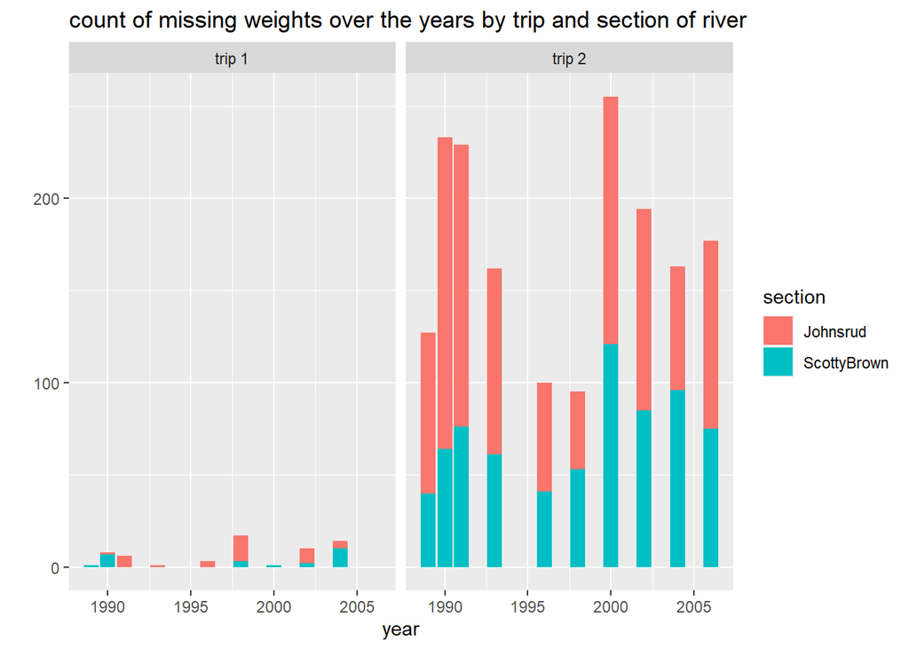

```r
#creating a new table for plotting
#https://chatgpt.com/share/67319b09-cb90-8013-b5a9-3482aec61d91

df_fish |>
  filter(is.na(weight)) |>
  ggplot(aes(x = year, fill = section)) +
  geom_bar() +
  facet_wrap(~ trip, labeller = as_labeller(function(trip) paste("trip", trip))) +
  labs(
        x = "year",
        y = "",
        title = "count of missing weights over the years by trip and section of river"
  )
```

## Rescaling the Data

If I wanted to rescale every quantitative variable in my dataset so that they only have values between 0 and 1, I could use this formula:

$$y_{scaled} = \frac{y_i - min\{y_1, y_2,..., y_n\}}{max\{y_1, y_2,..., y_n\}
- min\{y_1, y_2,..., y_n\}}$$

I might write the following `R` code to carry out the rescaling procedure for the `length` and `weight` columns of the `BlackfoorFish` data:

```r
fish <- df_fish |>
  mutate(length = (length - min(length, na.rm = TRUE)) /
           (max(length, na.rm = TRUE) - min(length, na.rm = TRUE)),
         weight = (weight - min(weight, na.rm = TRUE)) /
           (max(weight, na.rm = TRUE) - min(length, na.rm = TRUE)))
```

This process of duplicating an action multiple times can make it difficult to understand the intent of the process. *Additionally, it can make it very difficult to spot mistakes.*

**3. What is the mistake I made in the above rescaling code?**

The mistake made in the code above is in the second variable `weight` is being divided by the minimum length, instead of weight which is what we would need to rescale approportiately.

When you find yourself copy-pasting lines of code, it’s time to write a function, instead!

**4. Transform the repeated process above into a `rescale_01()` function. Your function should…**

- **… take a single vector as input.**
- **… return the rescaled vector.**

```r
#sources:
#help(range)

rescale_01 <- function(vec)
              {
                #input validation
                if(!is.numeric(vec))
                {
                  stop("inputted vector is not a numeric data type.")
                }

                if(length(vec) <= 1)
                {
                  stop("inputted vector must contain more than one element.")
                }
                range_val <- range(vec, na.rm = TRUE)
                #range_val[1] = min, range_val[2] = max
                rescaled = (vec - range_val[1]) / (range_val[2] - range_val[1])
                return(rescaled)
              }

#testing the function to make sure it works
df_fish |>
    select(weight) |>
    mutate(weight = rescale_01(weight))
```

```
# A tibble: 18,352 × 1
    weight
     <dbl>
 1 0.0374
 2 0.0406
 3 0.0524
 4 0.0588
 5 0.0641
 6 0.0812
 7 0.0363
 8 0.00855
 9 0.0171
10 0.00748
# ℹ 18,342 more rows
```

testing the function to ensure it works

```r
rescale_01(c("1", "2", "moo")) #should "throw" type error

rescale_01(C("1")) #should throw invalid length

#yea they throw errors.
```

**Efficiency**

Think about the efficiency of the function you wrote. Are you calling the **same** function multiple times? You might want to look into the `range()` function.

**5. Let’s incorporate some input validation into your function. Modify your previous code so that the function stops if …**

- **… the input vector is not numeric.**
- **… the length of the input vector is not greater than 1.**

**Modify Previous Code**

Do not create a new code chunk here – simply add these stops to your function above!

## Test Your Function

**6. Run the code below to test your function. Verify that the maximum of your rescaled vector is 1 and the minimum is 0!**

```r
x <- c(1:25, NA)

rescaled <- rescale_01(x)
min(rescaled, na.rm = TRUE)
```

```
[1] 0
```

```r
max(rescaled, na.rm = TRUE)
```

```
[1] 1
```

Next, let’s test the function on the `length` column of the `BlackfootFish` data.

**7. The code below makes a histogram of the original values of `length`. Add a plot of the rescaled values of `length`. Output your plots side-by-side, so the reader can confirm the only aspect that has changed is the scale.**

**Warning**

This will require you to call your `rescale_01()` function within a `mutate()` statement in order to create a `length_scaled` variable.

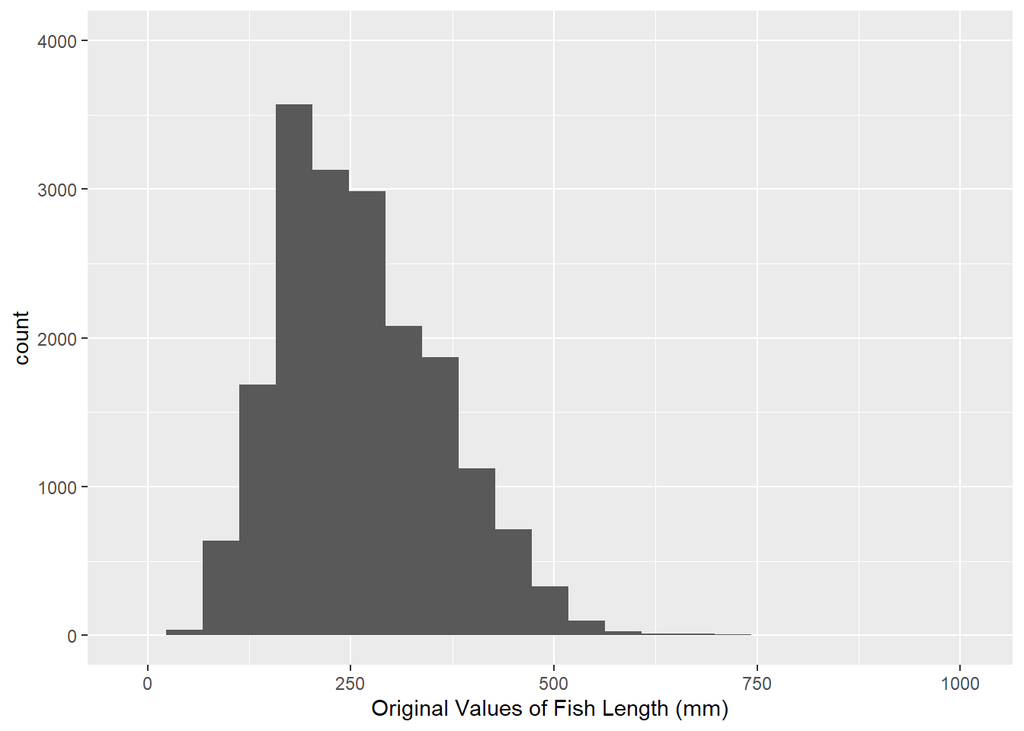

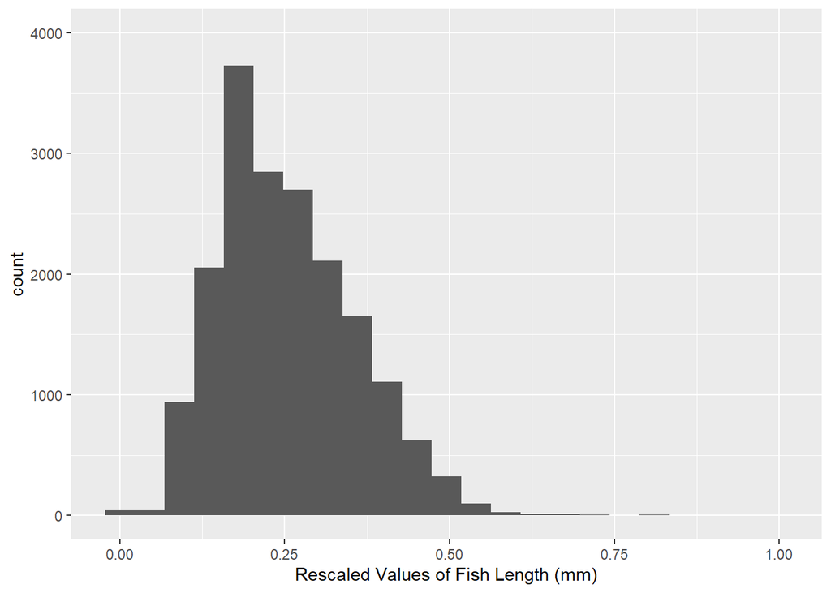

```r
#sources:
#https://r-charts.com/distribution/histogram-binwidth-ggplot2/
#https://quarto.org/docs/authoring/figures.html

df_fish |>
  ggplot(aes(x = length)) +
  geom_histogram(binwidth = 45) +
  labs(x = "Original Values of Fish Length (mm)") +
  scale_y_continuous(limits = c(0,4000))
# Code for Q7 plot.

df_fish |>
  ggplot(aes(x = rescale_01(length))) +
  geom_histogram(binwidth = 0.045) +
  labs(x = "Rescaled Values of Fish Length (mm)") +
  scale_y_continuous(limits = c(0,4000))
```

**Tip**

1. Set the y-axis limits for both plots to go from 0 to 4000 to allow for direct comparison across plots.
2. Pay attention to `binwidth`!
3. Use a Quarto code chunk option to put the plots side-by-side.

## Use Variables within a Dataset

Suppose you would like for your `rescale()` function to perform operations on a **variable within a dataset**. Ideally, your function would take in a data frame and a variable name as inputs and return a data frame where the variable has been rescaled.

**8. Create a `rescale_column()` function that accepts two arguments:**

- **a dataframe**
- **the name(s) of the variable(s) to be rescaled**

**The body of the function should call the original `rescale_01()` function you wrote previously. Your solution MUST use one of the `rlang` options from class.**

**Tip**

If you are struggling with this task, I recommend looking back over the [data frame functions](https://r4ds.hadley.nz/functions.html#data-frame-functions) section of R for Data Science!

```r
#sources:
#https://chatgpt.com/share/673139f3-590c-8013-934d-40567b76d33c

rescale_column <- function(df, cNames)
                  {
                    #validation checking
                    if(!is.data.frame(df))
                    {
                      stop("dataframe inputted is not a dataframe")
                    }

                    if(!all(cNames %in% colnames(df)))
                    {
                      stop("at least one column names does not exist in the dataframe provided.")
                    }

                    rescaled <- df |>
                      mutate(
                              across(all_of(cNames), ~
                                  {
                                      if (!is.numeric(.))
                                      {
                                        stop(englue("column {.var} must be numeric data type"))
                                      }
                                      if (length(.) <= 1)
                                      {
                                        stop(englue("column {.var} must have more than one value."))
                                      }

                                      range_ = range(., na.rm = TRUE)
                                      (. - range_[1]) / (range_[2] - range_[1])
                                  },
                                  .names = "{.col}")
                            )

                    return(rescaled)
}
```

**9. Use your `rescale_column()` function to rescale *both* the `length` and `weight` columns.**

**Warning**

I expect that you carry out this process by calling the `rescale_column()` function only ONE time!

```r
rescale_column(df_fish, c("length", "weight"))
```

```
# A tibble: 18,352 × 7
    trip  mark length  weight  year section  species
   <dbl> <dbl>  <dbl>   <dbl> <dbl> <chr>    <chr>
 1     1     0  0.280 0.0374   1989 Johnsrud RBT
 2     1     0  0.280 0.0406   1989 Johnsrud RBT
 3     1     0  0.277 0.0524   1989 Johnsrud RBT
 4     1     0  0.315 0.0588   1989 Johnsrud RBT
 5     1     0  0.305 0.0641   1989 Johnsrud RBT
 6     1     0  0.358 0.0812   1989 Johnsrud RBT
 7     1     0  0.261 0.0363   1989 Johnsrud RBT
 8     1     0  0.148 0.00855  1989 Johnsrud RBT
 9     1     0  0.203 0.0171   1989 Johnsrud RBT
10     1     0  0.145 0.00748  1989 Johnsrud RBT
# ℹ 18,342 more rows
```